# STATS 769 Lab 2

Xuan Fang ID:193046965

8/13/2020

# Import CSV files

Import the six CSV files into R and combine them into a single data frame.

```r
## Read 6 CVS files into R ()
## and, combine the six files into a single data frame:
 cases <- do.call(rbind, lapply(sprintf("/course/COVID/covid-0%d.csv", 1:6), read.csv))

# cases <- do.call(rbind, lapply(sprintf("covid-0%d.csv", 1:6), read.csv))

dim(cases)
```

```
## [1] 339547     33
```

```r
N <- nrow(cases)
```

## Commentary:

- The data consist of around $339,547$ individual COVIS cases spread across six CSV files. We use read.csv() function to import them into R. After reading the six files, we end up with 6 data frames and then combine them by rows into a single data frame using rbind() function.
- There are 33 variables in the data set, but our interest is going to focus on the relationship between the number of days from disease onset to time of death and patient age.

# Task 1: Create a variable `years`

Exploration of variable `age`:

```r
class(cases$age)
```

```
## [1] "character"
```

## Commentary:

The `age` variable must contains some unusual (non-numeric) values in it because it is read in as a character column.

```r
head(cases$age[grep("[a-zA-Z]", cases$age)], 10)
```

```
##  [1] "6 weeks"   "18 months" "18 month"  "7 months"  "4 months"  "13 month"
##  [7] "18 month"  "5 months"  "8 month"   "6 months"
```

## Commentary:

There are text characters contained in the `age` variable. It shows that the age for some young patients has been recorded with a time unit (weeks/month/months).

An easy approach is to coerce character value to numeric, which will generate NA values for any ages that contain a time unit.

```r
## Coerce to numeric
years <- as.numeric(as.character(cases$age))
```

This approach seems to lose a chunk of cases (26,535).

```r
##  Exploration: the total number of NAs in the 'years' variable (26,535):
sum(is.na(years))
```

```
## [1] 26535
```

A large number of cases contain very old patients were lost. However, the cases of we lost don’t contain records of deaths (by using sum(deceased[is.na(years)] to check out)).

```r
table(cases$age[is.na(years)])
```

```
##
##  11 month  13 month  18 month 18 months  4 months   5 month  5 months  6 months
##         1         1         2         1         1         1         1         1
##   6 weeks  7 months   8 month       80+       85+   9 month       90+
##         1         1         2     20203       112         1      5972
```

We choose to keep ages between 0 and 100 exclusive and turn everything else into NA. This does not lose too many more cases (28,066).

```r
years[!is.na(years) & (years <= 0 | years >= 100)] <- NA

## Exploration: the total number of NAs in the 'years' variable (28,066):
sum(is.na(years))
```

```
## [1] 28066
```

Basic exploration of new variable `years`:

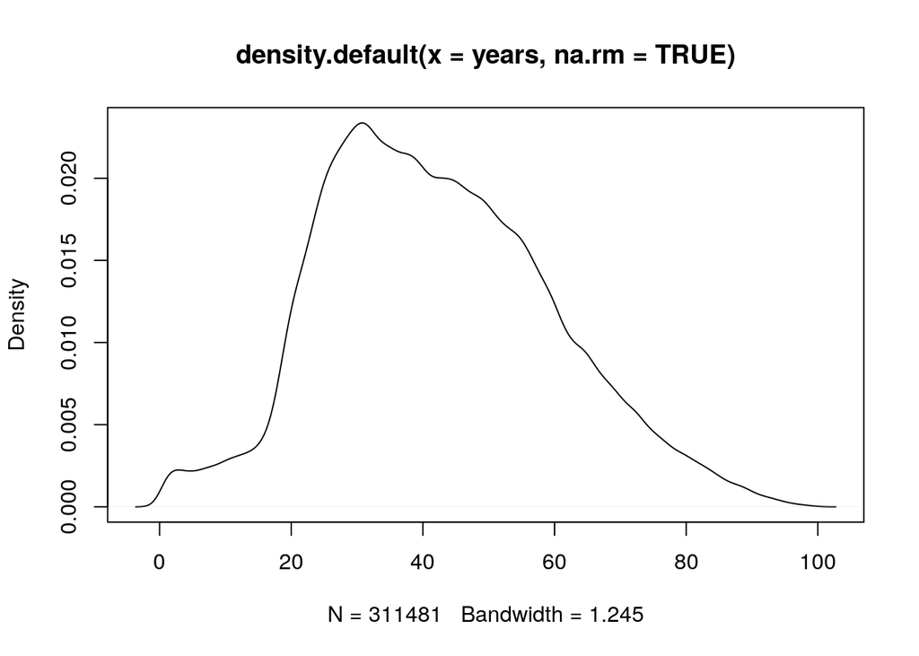

```r
plot(density(years, na.rm=TRUE))
```

## Commentary:

The plot of the `years` distribution shows that we have noticeable fewer COVID cases at extreme ages (very young age and very advanced ages), which might make our estimate of the number of days from disease onset to time of death less reliable for those ages.

# Task 2: Create `deceased` variable

Exploring the `outcome` variable:

```r
table(cases$outcome)
```

```
##
##                                             Alive                     Dead
##                   305512                       45                        6
##                    Death                 Deceased                     Died
##                        2                      408                        1
##               Discharged             Hospitalized      Receiving Treatment
##                        2                    28468                        1
##                Recovered                   Stable          Under treatment
##                      158                        5                       14
##       critical condition                     dead                    death
##                        1                        1                       18
##                     died                discharge               discharged
##                      859                      141                       80
##                recovered released from quarantine           severe illness
##                     3650                        2                        1
##                   stable         stable condition                 unstable
##                       60                      111                        1
```

## Commentary:

We find seven values in the `outcome` column could represent the failure to survive, which are: “death”, “died”, “Died”, “Dead”, “Death”, “Deceased” and “dead”. Note that If the `outcome` value is empty, we will assume that the patient is alive.

Our approach: if the `outcome` value matches one of the seven values, then set the `deceased` value to be ‘TRUE’; and, everything else to be ‘FALSE’:

```r
## Creating the `deceased` variable:
deceased <- cases$outcome %in% c("death", "died", "Died", "Dead",
                                                    "Death", "Deceased", "dead")

## Exploration: the total number of death (1295):
table(deceased)
```

```
## deceased
##  FALSE   TRUE
## 338252   1295
```

# Task 3: Create a new variable `days`

```r
## Calculate the difference between variable `date_onset_symptoms` and variable `date_death_or_discharge`
days <- as.Date(as.character(cases$date_death_or_discharge), format="%d.%m.%Y")-as.Date(as.character(cases$date_onset_symptoms), format="%d.%m.%Y")

## We set missing data and the records not for date of death to NA:
days[is.na(days)|deceased == FALSE] <- NA

## Coerce to numeric
days <- as.numeric(days)

## Take a look at the frequency table:
table(days)
```

```
## days
## -19  -3   0   1   2   3   4   5   6   7   8   9  10  11  12  13  14  15  16  17
##   1   1  18  30  31  30  25  28  40  29  33  23  29  25  25  33  25  10  16  11
##  18  19  20  21  22  23  24  25  26  27  28  29  30  31  32  33  34  36  37  38
##  14  11  10   8  11   8   7   5   1   1   2   2   3   2   4   2   1   1   2   2
##  39  41  44  45  48  49  50  53  54  55  58  77
##   3   3   2   3   1   1   1   1   1   1   1   1
```

## Commentary:

We find two negative values in the new variable `days`, so it is reasonable to set them to NA.

```r
## Set negative values to NA:
days[days<0] <- NA
table(days)
```

```
## days
##  0  1  2  3  4  5  6  7  8  9 10 11 12 13 14 15 16 17 18 19 20 21 22 23 24 25
## 18 30 31 30 25 28 40 29 33 23 29 25 25 33 25 10 16 11 14 11 10  8 11  8  7  5
## 26 27 28 29 30 31 32 33 34 36 37 38 39 41 44 45 48 49 50 53 54 55 58 77
##  1  1  2  2  3  2  4  2  1  1  2  2  3  3  2  3  1  1  1  1  1  1  1  1
```

```r
## Exploration: the total number of NAs in the 'days' variable (338,970):
sum(is.na(days))
```

```
## [1] 338970
```

```r
## Exploration: the total number of data we got in the 'days' variable (577):
sum(!is.na(days))
```

```
## [1] 577
```

## Commentary:

We only get $577$ records for the number of days from disease onset to time of death, a tiny fraction of data in the whole $339,547$ records. The data we got might be very different from the data we don’t get, so our model based on those data might not be reliable.

Basic exploration of new variable `days`:

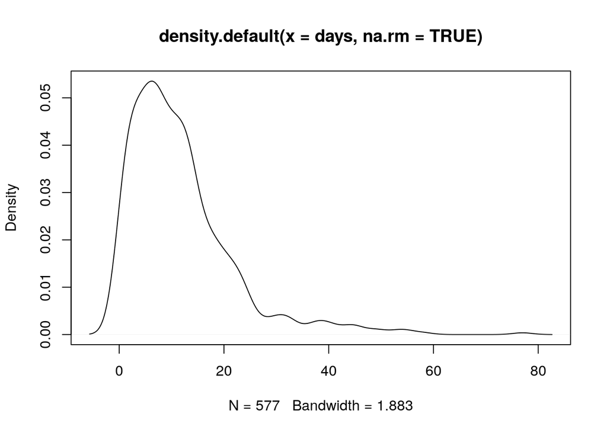

```r
plot(density(days, na.rm = TRUE)) #right skewed
```

## Commentary:

The plot of the `days` distribution is right skewed. Thus, we probably need to transform it to make it more symmetric.

# Task 4: Transform the `days` variable to make it more symmetric

```r
## Transformation (logged days):
logdays <- log(days)
table(logdays)
```

```
## logdays
##              -Inf                 0 0.693147180559945  1.09861228866811
##                18                30                31                30
##  1.38629436111989   1.6094379124341  1.79175946922805  1.94591014905531
##                25                28                40                29
##  2.07944154167984  2.19722457733622  2.30258509299405  2.39789527279837
##                33                23                29                25
##    2.484906649788  2.56494935746154  2.63905732961526  2.70805020110221
##                25                33                25                10
##  2.77258872223978  2.83321334405622  2.89037175789616  2.94443897916644
##                16                11                14                11
##  2.99573227355399  3.04452243772342  3.09104245335832  3.13549421592915
##                10                 8                11                 8
##  3.17805383034795   3.2188758248682  3.25809653802148  3.29583686600433
##                 7                 5                 1                 1
##   3.3322045101752  3.36729582998647  3.40119738166216  3.43398720448515
##                 2                 2                 3                 2
##  3.46573590279973  3.49650756146648  3.52636052461616  3.58351893845611
##                 4                 2                 1                 1
##  3.61091791264422  3.63758615972639  3.66356164612965  3.71357206670431
##                 2                 2                 3                 3
##  3.78418963391826  3.80666248977032  3.87120101090789  3.89182029811063
##                 2                 3                 1                 1
##  3.91202300542815  3.97029191355212  3.98898404656427  4.00733318523247
##                 1                 1                 1                 1
##  4.06044301054642  4.34380542185368
##                 1                 1
```

## Commentary:

Since zero value will be transformed to -Inf. In that case, we need convert -Inf to NA.

```r
## Set non-positive NA:
logdays[!is.finite(logdays)] <-  NA
```

Distribution of days after transforming:

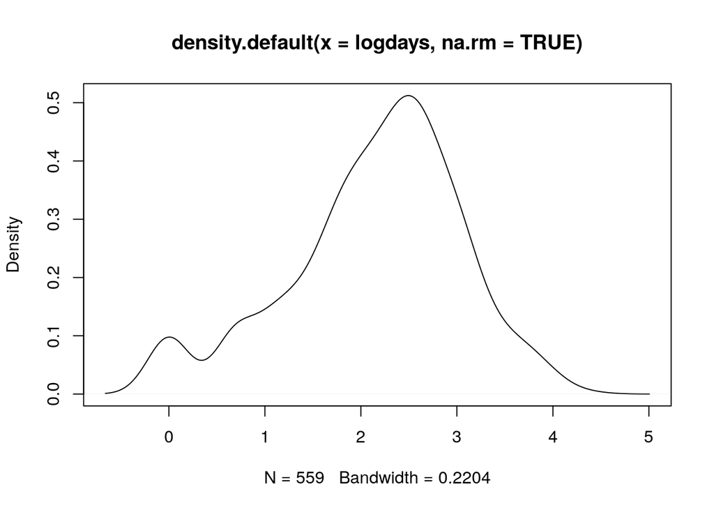

```r
plot(density(logdays, na.rm=TRUE))
```

# Task 5: Split the data 80/20 into training and test sets

Make a random split, with 80% of the data in the training set.

```r
set.seed(123)
train <- sample(seq(N), N*0.8)

yTrain <- logdays[train]
xTrain <- years[train]
```

The test set contains the remainder of the data.

```r
yTest <- logdays[-train]
xTest <- years[-train]
```

## Commentary:

- We use the set.seed() function to make sure our procedure is reproducible.
- Then, we use the sample() function to choose a sample from the numbers of $339,547$ rows from the initial data set, and the size of our sample is 80% of the number of rows in the initial data set.
- Finally, we use the selected rows (in the previous step) to subset the original data set as the training set and those non-selected rows to subset the original data set as the test set.

In the training data set, the relationship between `logdays` and `years`:

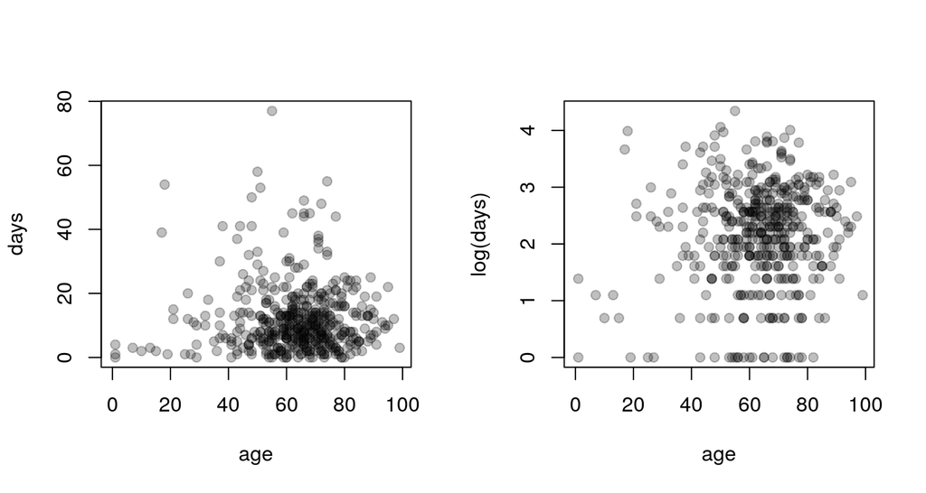

```r
par(mfrow=c(1, 2))
plot(xTrain, days[train], pch = 19, col = grey(0, 0.25), xlab = "age", ylab = "days")
plot(xTrain, yTrain, pch = 19, col = grey(0, 0.25), xlab = "age", ylab = "log(days)")
```

## Commentary:

The plots show the trend between days of death and age is not apparent.

# Task 6 (Model fitting using a training set)

Fit and assess a linear regression model that predicts `days` from `years`.

There are missing values in the `years` variable and `logdays` variable, but these are automatically dropped from the analysis.

```r
fitLM <- lm(yTrain ~ xTrain)
summary(fitLM)
```

```
##
## Call:
## lm(formula = yTrain ~ xTrain)
##
## Residuals:
##     Min      1Q  Median      3Q     Max
## -2.2492 -0.4622  0.1049  0.5844  2.2106
##
## Coefficients:
##             Estimate Std. Error t value Pr(>|t|)
## (Intercept) 1.896825   0.178138  10.648   <2e-16 ***
## xTrain      0.004298   0.002725   1.577    0.115
## ---
## Signif. codes:  0 '***' 0.001 '**' 0.01 '*' 0.05 '.' 0.1 ' ' 1
##
## Residual standard error: 0.9008 on 446 degrees of freedom
##   (271189 observations deleted due to missingness)
## Multiple R-squared:  0.005548,   Adjusted R-squared:  0.003318
## F-statistic: 2.488 on 1 and 446 DF,  p-value: 0.1154
```

## Commentary:

The relationship between the days of death and age is not significant. R-squared is 0.55%, suggesting the model is not useful.

Simple overall mean:

```r
(fitMean <- mean(yTrain, na.rm=TRUE))
```

```
## [1] 2.165637
```